# Starbucks Capstone Challenge

### Introduction

This data set contains simulated data that mimics customer behavior on the Starbucks rewards mobile app. Once every few days, Starbucks sends out an offer to users of the mobile app. An offer can be merely an advertisement for a drink or an actual offer such as a discount or BOGO (buy one get one free). Some users might not receive any offer during certain weeks.

Not all users receive the same offer, and that is the challenge to solve with this data set.

Your task is to combine transaction, demographic and offer data to determine which demographic groups respond best to which offer type. This data set is a simplified version of the real Starbucks app because the underlying simulator only has one product whereas Starbucks actually sells dozens of products.

Every offer has a validity period before the offer expires. As an example, a BOGO offer might be valid for only 5 days. You'll see in the data set that informational offers have a validity period even though these ads are merely providing information about a product; for example, if an informational offer has 7 days of validity, you can assume the customer is feeling the influence of the offer for 7 days after receiving the advertisement.

You'll be given transactional data showing user purchases made on the app including the timestamp of purchase and the amount of money spent on a purchase. This transactional data also has a record for each offer that a user receives as well as a record for when a user actually views the offer. There are also records for when a user completes an offer.

Keep in mind as well that someone using the app might make a purchase through the app without having received an offer or seen an offer.

### Example

To give an example, a user could receive a discount offer buy 10 dollars get 2 off on Monday. The offer is valid for 10 days from receipt. If the customer accumulates at least 10 dollars in purchases during the validity period, the customer completes the offer.

However, there are a few things to watch out for in this data set. Customers do not opt into the offers that they receive; in other words, a user can receive an offer, never actually view the offer, and still complete the offer. For example, a user might receive the "buy 10 dollars get 2 dollars off offer", but the user never opens the offer during the 10 day validity period. The customer spends 15 dollars during those ten days. There will be an offer completion record in the data set; however, the customer was not influenced by the offer because the customer never viewed the offer.

### Cleaning

This makes data cleaning especially important and tricky.

You'll also want to take into account that some demographic groups will make purchases even if they don't receive an offer. From a business perspective, if a customer is going to make a 10 dollar purchase without an offer anyway, you wouldn't want to send a buy 10 dollars get 2 dollars off offer. You'll want to try to assess what a certain demographic group will buy when not receiving any offers.

### Final Advice

Because this is a capstone project, you are free to analyze the data any way you see fit. For example, you could build a machine learning model that predicts how much someone will spend based on demographics and offer type. Or you could build a model that predicts whether or not someone will respond to an offer. Or, you don't need to build a machine learning model at all. You could develop a set of heuristics that determine what offer you should send to each customer (i.e., 75 percent of women customers who were 35 years old responded to offer A vs 40 percent from the same demographic to offer B, so send offer A).

# Data Sets

The data is contained in three files:

- portfolio.json - containing offer ids and meta data about each offer (duration, type, etc.)
- profile.json - demographic data for each customer
- transcript.json - records for transactions, offers received, offers viewed, and offers completed

Here is the schema and explanation of each variable in the files:

**portfolio.json**

- id (string) - offer id
- offer_type (string) - type of offer ie BOGO, discount, informational
- difficulty (int) - minimum required spend to complete an offer
- reward (int) - reward given for completing an offer
- duration (int) - time for offer to be open, in days
- channels (list of strings)

**profile.json**

- age (int) - age of the customer
- became_member_on (int) - date when customer created an app account
- gender (str) - gender of the customer (note some entries contain 'O' for other rather than M or F)
- id (str) - customer id
- income (float) - customer's income

**transcript.json**

- event (str) - record description (ie transaction, offer received, offer viewed, etc.)
- person (str) - customer id
- time (int) - time in hours since start of test. The data begins at time t=0
- value - (dict of strings) - either an offer id or transaction amount depending on the record

**Note:** If you are using the workspace, you will need to go to the terminal and run the command `conda update pandas` before reading in the files. This is because the version of pandas in the workspace cannot read in the transcript.json file correctly, but the newest version of pandas can. You can access the termnal from the orange icon in the top left of this notebook.

You can see how to access the terminal and how the install works using the two images below. First you need to access the terminal:

[figure not shown]

Then you will want to run the above command:

[figure not shown]

Finally, when you enter back into the notebook (use the jupyter icon again), you should be able to run the below cell without any errors.

## 1. Load the data

```python
import pandas as pd
import numpy as np
import math
import json
from pandas.io.json import json_normalize
from datetime import datetime
from tqdm import tqdm

from sklearn.preprocessing import StandardScaler
from sklearn.decomposition import PCA
from sklearn.cluster import KMeans
from sklearn.metrics import silhouette_samples, silhouette_score
from sklearn.manifold import TSNE

import matplotlib.pyplot as plt
import seaborn as sns
% matplotlib inline
```

```python
# read in the json files
portfolio = pd.read_json('data/portfolio.json', orient='records', lines=True)
profile = pd.read_json('data/profile.json', orient='records', lines=True)
transcript = pd.read_json('data/transcript.json', orient='records', lines=True)
```

```python
portfolio
```

|  | channels | difficulty | duration | id | offer_type | reward |
| --- | --- | --- | --- | --- | --- | --- |
| 0 | [email, mobile, social] | 10 | 7 | ae264e3637204a6fb9bb56bc8210ddfd | bogo | 10 |
| 1 | [web, email, mobile, social] | 10 | 5 | 4d5c57ea9a6940dd891ad53e9dbe8da0 | bogo | 10 |
| 2 | [web, email, mobile] | 0 | 4 | 3f207df678b143eea3cee63160fa8bed | informational | 0 |
| 3 | [web, email, mobile] | 5 | 7 | 9b98b8c7a33c4b65b9aebfe6a799e6d9 | bogo | 5 |
| 4 | [web, email] | 20 | 10 | 0b1e1539f2cc45b7b9fa7c272da2e1d7 | discount | 5 |
| 5 | [web, email, mobile, social] | 7 | 7 | 2298d6c36e964ae4a3e7e9706d1fb8c2 | discount | 3 |
| 6 | [web, email, mobile, social] | 10 | 10 | fafdcd668e3743c1bb461111dcafc2a4 | discount | 2 |
| 7 | [email, mobile, social] | 0 | 3 | 5a8bc65990b245e5a138643cd4eb9837 | informational | 0 |
| 8 | [web, email, mobile, social] | 5 | 5 | f19421c1d4aa40978ebb69ca19b0e20d | bogo | 5 |
| 9 | [web, email, mobile] | 10 | 7 | 2906b810c7d4411798c6938adc9daaa5 | discount | 2 |

```python
profile.head()
```

|  | age | became_member_on | gender | id | income |
| --- | --- | --- | --- | --- | --- |
| 0 | 118 | 20170212 | None | 68be06ca386d4c31939f3a4f0e3dd783 | NaN |
| 1 | 55 | 20170715 | F | 0610b486422d4921ae7d2bf64640c50b | 112000.0 |
| 2 | 118 | 20180712 | None | 38fe809add3b4fcf9315a9694bb96ff5 | NaN |
| 3 | 75 | 20170509 | F | 78afa995795e4d85b5d9ceeca43f5fef | 100000.0 |
| 4 | 118 | 20170804 | None | a03223e636434f42ac4c3df47e8bac43 | NaN |

```python
transcript.head(5)
```

|  | event | person | time | value |
| --- | --- | --- | --- | --- |
| 0 | offer received | 78afa995795e4d85b5d9ceeca43f5fef | 0 | {'offer id': '9b98b8c7a33c4b65b9aebfe6a799e6d9'} |
| 1 | offer received | a03223e636434f42ac4c3df47e8bac43 | 0 | {'offer id': '0b1e1539f2cc45b7b9fa7c272da2e1d7'} |
| 2 | offer received | e2127556f4f64592b11af22de27a7932 | 0 | {'offer id': '2906b810c7d4411798c6938adc9daaa5'} |
| 3 | offer received | 8ec6ce2a7e7949b1bf142def7d0e0586 | 0 | {'offer id': 'fafdcd668e3743c1bb461111dcafc2a4'} |
| 4 | offer received | 68617ca6246f4fbc85e91a2a49552598 | 0 | {'offer id': '4d5c57ea9a6940dd891ad53e9dbe8da0'} |

```python
print('The offer portfolio dataset shape is: {}'.format(portfolio.shape))
print('The customer demographic profile dataset shape is: {}'.format(profile.shape))
print('The transaction transcript dataset shape is: {}'.format(transcript.shape))
```

```
The offer portfolio dataset shape is: (10, 6)
The customer demographic profile dataset shape is: (17000, 5)
The transaction transcript dataset shape is: (306534, 4)
```

## 2. Clean the data

### 2.1. Clean portfolio dataset

```python
# Split the channels column into separate columns
channel = ['web', 'email', 'mobile', 'social']
for c in channel:
    portfolio[c]  = portfolio['channels'].apply(lambda x: 1 if c in x else 0)
```

```python
# Encode the id combining offer type, difficulty, reward and duration information
portfolio['offer'] = portfolio.agg('{0[offer_type]}_lev{0[difficulty]}_rew{0[reward]}_day{0[duration]}'.format, axis=1)
portfolio
```

|  | channels | difficulty | duration | id | offer_type | reward | web | email | mobile | social | offer |
| --- | --- | --- | --- | --- | --- | --- | --- | --- | --- | --- | --- |
| 0 | [email, mobile, social] | 10 | 7 | ae264e3637204a6fb9bb56bc8210ddfd | bogo | 10 | 0 | 1 | 1 | 1 | bogo_lev10_rew10_day7 |
| 1 | [web, email, mobile, social] | 10 | 5 | 4d5c57ea9a6940dd891ad53e9dbe8da0 | bogo | 10 | 1 | 1 | 1 | 1 | bogo_lev10_rew10_day5 |
| 2 | [web, email, mobile] | 0 | 4 | 3f207df678b143eea3cee63160fa8bed | informational | 0 | 1 | 1 | 1 | 0 | informational_lev0_rew0_day4 |
| 3 | [web, email, mobile] | 5 | 7 | 9b98b8c7a33c4b65b9aebfe6a799e6d9 | bogo | 5 | 1 | 1 | 1 | 0 | bogo_lev5_rew5_day7 |
| 4 | [web, email] | 20 | 10 | 0b1e1539f2cc45b7b9fa7c272da2e1d7 | discount | 5 | 1 | 1 | 0 | 0 | discount_lev20_rew5_day10 |
| 5 | [web, email, mobile, social] | 7 | 7 | 2298d6c36e964ae4a3e7e9706d1fb8c2 | discount | 3 | 1 | 1 | 1 | 1 | discount_lev7_rew3_day7 |
| 6 | [web, email, mobile, social] | 10 | 10 | fafdcd668e3743c1bb461111dcafc2a4 | discount | 2 | 1 | 1 | 1 | 1 | discount_lev10_rew2_day10 |
| 7 | [email, mobile, social] | 0 | 3 | 5a8bc65990b245e5a138643cd4eb9837 | informational | 0 | 0 | 1 | 1 | 1 | informational_lev0_rew0_day3 |
| 8 | [web, email, mobile, social] | 5 | 5 | f19421c1d4aa40978ebb69ca19b0e20d | bogo | 5 | 1 | 1 | 1 | 1 | bogo_lev5_rew5_day5 |
| 9 | [web, email, mobile] | 10 | 7 | 2906b810c7d4411798c6938adc9daaa5 | discount | 2 | 1 | 1 | 1 | 0 | discount_lev10_rew2_day7 |

```python
# Drop channels column
portfolio= portfolio.drop(['channels'], axis=1)
```

### 2.2. Clean profile dataset

##### 2.2.1. Handling missing value

```python
# Checking missing value
profile.isna().sum()
```

```
age                    0
became_member_on       0
gender              2175
id                     0
income              2175
dtype: int64
```

```python
# For gender, checking the different categorisation
profile['gender'].value_counts()
```

```
M    8484
F    6129
O     212
Name: gender, dtype: int64
```

```python
# Fill null values for gender with 'N'
profile['gender'] = profile['gender'].fillna('N')

# Split genders columns by in separate column by gender
gender = ['F', 'M','O']
for g in gender:
    profile[g]  = profile['gender'].apply(lambda x: 1 if x==g else 0)
```

```python
profile.sample(5)
```

|  | age | became_member_on | gender | id | income | F | M | O |
| --- | --- | --- | --- | --- | --- | --- | --- | --- |
| 7621 | 64 | 20180722 | F | 0622afdf88de4cb4b0b59f08312c344c | 66000.0 | 1 | 0 | 0 |
| 1337 | 51 | 20180116 | F | 5e188ec73c3e40c894ef0ff0aa847ec0 | 76000.0 | 1 | 0 | 0 |
| 10071 | 76 | 20180623 | M | c52343cf47e84dadbedd0b9632d626ec | 51000.0 | 0 | 1 | 0 |
| 3711 | 77 | 20170524 | F | 1eae2b68358845a497404afcea2f0aa0 | 62000.0 | 1 | 0 | 0 |
| 9231 | 41 | 20160610 | M | f26e371122ca443b957ce94bcd37f48d | 61000.0 | 0 | 1 | 0 |

```python
# Checking the null profile
null_profile = profile[pd.isnull(profile).any(axis=1)]
null_profile.sample(5)
```

|  | age | became_member_on | gender | id | income | F | M | O |
| --- | --- | --- | --- | --- | --- | --- | --- | --- |
| 9538 | 118 | 20170419 | N | d0a70db109564df1be5f0cfcf3296642 | NaN | 0 | 0 | 0 |
| 8649 | 118 | 20171129 | N | dacf98c8c33a41cb8594133ce622199c | NaN | 0 | 0 | 0 |
| 15390 | 118 | 20170824 | N | e791cf28bcb14311a8ecd7eae7d3e6a7 | NaN | 0 | 0 | 0 |
| 1023 | 118 | 20180502 | N | 44b02bac48694f92aa88cc04e597f6f0 | NaN | 0 | 0 | 0 |
| 4767 | 118 | 20180619 | N | 3f23b1c6fdf04e998edf32892e73a604 | NaN | 0 | 0 | 0 |

```python
null_profile.describe()
```

|  | age | became_member_on | income | F | M | O |
| --- | --- | --- | --- | --- | --- | --- |
| count | 2175.0 | 2.175000e+03 | 0.0 | 2175.0 | 2175.0 | 2175.0 |
| mean | 118.0 | 2.016804e+07 | NaN | 0.0 | 0.0 | 0.0 |
| std | 0.0 | 1.009105e+04 | NaN | 0.0 | 0.0 | 0.0 |
| min | 118.0 | 2.013080e+07 | NaN | 0.0 | 0.0 | 0.0 |
| 25% | 118.0 | 2.016070e+07 | NaN | 0.0 | 0.0 | 0.0 |
| 50% | 118.0 | 2.017073e+07 | NaN | 0.0 | 0.0 | 0.0 |
| 75% | 118.0 | 2.017123e+07 | NaN | 0.0 | 0.0 | 0.0 |
| max | 118.0 | 2.018073e+07 | NaN | 0.0 | 0.0 | 0.0 |

**Note:** It seems that for customers with no age, gender, income information, the default age is set at 118.

```python
# Replace age 118 with nan for consistency
profile['age'] = profile['age'].replace(118, np.nan)
```

##### 2.2.2. Cleaning membership date

```python
# Convert float to datetime
profile['became_member_on'] = profile['became_member_on'].apply(lambda x: datetime.strptime(str(x), '%Y%m%d'))
```

```python
# Determine the membership subcription time range
first_membership_time = profile['became_member_on'].sort_values(ascending=False).tail(1).iloc[0]
last_membership_time = profile['became_member_on'].sort_values(ascending=False).head(1).iloc[0]
print('The membership subcription time ranges between {:%Y-%m-%d} and {:%Y-%m-%d}'.format(first_membership_time,last_membership_time))
```

```
The membership subcription time ranges between 2013-07-29 and 2018-07-26
```

```python
# Calculate the each customer membership time in days
profile['membership_days'] = (datetime(2018,7,26) - profile['became_member_on']).dt.days
```

```python
profile.head()
```

|  | age | became_member_on | gender | id | income | F | M | O | membership_days |
| --- | --- | --- | --- | --- | --- | --- | --- | --- | --- |
| 0 | NaN | 2017-02-12 | N | 68be06ca386d4c31939f3a4f0e3dd783 | NaN | 0 | 0 | 0 | 529 |
| 1 | 55.0 | 2017-07-15 | F | 0610b486422d4921ae7d2bf64640c50b | 112000.0 | 1 | 0 | 0 | 376 |
| 2 | NaN | 2018-07-12 | N | 38fe809add3b4fcf9315a9694bb96ff5 | NaN | 0 | 0 | 0 | 14 |
| 3 | 75.0 | 2017-05-09 | F | 78afa995795e4d85b5d9ceeca43f5fef | 100000.0 | 1 | 0 | 0 | 443 |
| 4 | NaN | 2017-08-04 | N | a03223e636434f42ac4c3df47e8bac43 | NaN | 0 | 0 | 0 | 356 |

##### 2.2.3. Checking duplicates

```python
profile['id'].duplicated().sum()
```

```
0
```

##### 2.2.4. Profile dataset summary

```python
profile.describe()
```

|  | age | income | F | M | O | membership_days |
| --- | --- | --- | --- | --- | --- | --- |
| count | 14825.000000 | 14825.000000 | 17000.000000 | 17000.000000 | 17000.000000 | 17000.000000 |
| mean | 54.393524 | 65404.991568 | 0.360529 | 0.499059 | 0.012471 | 517.449882 |
| std | 17.383705 | 21598.299410 | 0.480168 | 0.500014 | 0.110977 | 411.223904 |
| min | 18.000000 | 30000.000000 | 0.000000 | 0.000000 | 0.000000 | 0.000000 |
| 25% | 42.000000 | 49000.000000 | 0.000000 | 0.000000 | 0.000000 | 208.000000 |
| 50% | 55.000000 | 64000.000000 | 0.000000 | 0.000000 | 0.000000 | 358.000000 |
| 75% | 66.000000 | 80000.000000 | 1.000000 | 1.000000 | 0.000000 | 791.000000 |
| max | 101.000000 | 120000.000000 | 1.000000 | 1.000000 | 1.000000 | 1823.000000 |

**Preliminary observations:**

- The sample age range between the 1st & 3rd quartile is between 42 to 66
- The minimum income is 30,000
- The gender breakdown is as follow: 36% are female, 50% are male, 1.2% are O
- For 12.8% of the sample, there is no age, gender and income information (e.g. missing value) - Those profiles are dropped

### 2.3. Clean transcript dataset

```python
transcript.head(5)
```

|  | event | person | time | value |
| --- | --- | --- | --- | --- |
| 0 | offer received | 78afa995795e4d85b5d9ceeca43f5fef | 0 | {'offer id': '9b98b8c7a33c4b65b9aebfe6a799e6d9'} |
| 1 | offer received | a03223e636434f42ac4c3df47e8bac43 | 0 | {'offer id': '0b1e1539f2cc45b7b9fa7c272da2e1d7'} |
| 2 | offer received | e2127556f4f64592b11af22de27a7932 | 0 | {'offer id': '2906b810c7d4411798c6938adc9daaa5'} |
| 3 | offer received | 8ec6ce2a7e7949b1bf142def7d0e0586 | 0 | {'offer id': 'fafdcd668e3743c1bb461111dcafc2a4'} |
| 4 | offer received | 68617ca6246f4fbc85e91a2a49552598 | 0 | {'offer id': '4d5c57ea9a6940dd891ad53e9dbe8da0'} |

#### 2.3.1 Parse value columns by offer id, transaction amount, reward amount

```python
# Parse json into dataframe column
value = json_normalize(transcript['value'])
value.head(10)
```

|  | amount | offer id | offer_id | reward |
| --- | --- | --- | --- | --- |
| 0 | NaN | 9b98b8c7a33c4b65b9aebfe6a799e6d9 | NaN | NaN |
| 1 | NaN | 0b1e1539f2cc45b7b9fa7c272da2e1d7 | NaN | NaN |
| 2 | NaN | 2906b810c7d4411798c6938adc9daaa5 | NaN | NaN |
| 3 | NaN | fafdcd668e3743c1bb461111dcafc2a4 | NaN | NaN |
| 4 | NaN | 4d5c57ea9a6940dd891ad53e9dbe8da0 | NaN | NaN |
| 5 | NaN | f19421c1d4aa40978ebb69ca19b0e20d | NaN | NaN |
| 6 | NaN | 2298d6c36e964ae4a3e7e9706d1fb8c2 | NaN | NaN |
| 7 | NaN | 3f207df678b143eea3cee63160fa8bed | NaN | NaN |
| 8 | NaN | 0b1e1539f2cc45b7b9fa7c272da2e1d7 | NaN | NaN |
| 9 | NaN | 0b1e1539f2cc45b7b9fa7c272da2e1d7 | NaN | NaN |

```python
# Concat the dataframes
transaction = pd.concat([transcript, value], axis=1)
transaction = transaction.drop(['value'], axis=1)
transaction[transaction['person'] == '78afa995795e4d85b5d9ceeca43f5fef']
```

|  | event | person | time | amount | offer id | offer_id | reward |
| --- | --- | --- | --- | --- | --- | --- | --- |
| 0 | offer received | 78afa995795e4d85b5d9ceeca43f5fef | 0 | NaN | 9b98b8c7a33c4b65b9aebfe6a799e6d9 | NaN | NaN |
| 15561 | offer viewed | 78afa995795e4d85b5d9ceeca43f5fef | 6 | NaN | 9b98b8c7a33c4b65b9aebfe6a799e6d9 | NaN | NaN |
| 47582 | transaction | 78afa995795e4d85b5d9ceeca43f5fef | 132 | 19.89 | NaN | NaN | NaN |
| 47583 | offer completed | 78afa995795e4d85b5d9ceeca43f5fef | 132 | NaN | NaN | 9b98b8c7a33c4b65b9aebfe6a799e6d9 | 5.0 |
| 49502 | transaction | 78afa995795e4d85b5d9ceeca43f5fef | 144 | 17.78 | NaN | NaN | NaN |
| 53176 | offer received | 78afa995795e4d85b5d9ceeca43f5fef | 168 | NaN | 5a8bc65990b245e5a138643cd4eb9837 | NaN | NaN |
| 85291 | offer viewed | 78afa995795e4d85b5d9ceeca43f5fef | 216 | NaN | 5a8bc65990b245e5a138643cd4eb9837 | NaN | NaN |
| 87134 | transaction | 78afa995795e4d85b5d9ceeca43f5fef | 222 | 19.67 | NaN | NaN | NaN |
| 92104 | transaction | 78afa995795e4d85b5d9ceeca43f5fef | 240 | 29.72 | NaN | NaN | NaN |
| 141566 | transaction | 78afa995795e4d85b5d9ceeca43f5fef | 378 | 23.93 | NaN | NaN | NaN |
| 150598 | offer received | 78afa995795e4d85b5d9ceeca43f5fef | 408 | NaN | ae264e3637204a6fb9bb56bc8210ddfd | NaN | NaN |
| 163375 | offer viewed | 78afa995795e4d85b5d9ceeca43f5fef | 408 | NaN | ae264e3637204a6fb9bb56bc8210ddfd | NaN | NaN |
| 201572 | offer received | 78afa995795e4d85b5d9ceeca43f5fef | 504 | NaN | f19421c1d4aa40978ebb69ca19b0e20d | NaN | NaN |
| 218393 | transaction | 78afa995795e4d85b5d9ceeca43f5fef | 510 | 21.72 | NaN | NaN | NaN |
| 218394 | offer completed | 78afa995795e4d85b5d9ceeca43f5fef | 510 | NaN | NaN | ae264e3637204a6fb9bb56bc8210ddfd | 10.0 |
| 218395 | offer completed | 78afa995795e4d85b5d9ceeca43f5fef | 510 | NaN | NaN | f19421c1d4aa40978ebb69ca19b0e20d | 5.0 |
| 230412 | transaction | 78afa995795e4d85b5d9ceeca43f5fef | 534 | 26.56 | NaN | NaN | NaN |
| 262138 | offer viewed | 78afa995795e4d85b5d9ceeca43f5fef | 582 | NaN | f19421c1d4aa40978ebb69ca19b0e20d | NaN | NaN |

```python
# Combine "offer id" and "offer_id" columns, then drop offer_id column
transaction['offer id'] = transaction.apply(lambda x: x['offer_id'] if pd.notna(x['offer_id']) else x['offer id'], axis=1)
transaction = transaction.drop(['offer_id'], axis=1)
```

```python
# Checking the results
transaction[transaction['person'] == '78afa995795e4d85b5d9ceeca43f5fef']
```

|  | event | person | time | amount | offer id | reward |
| --- | --- | --- | --- | --- | --- | --- |
| 0 | offer received | 78afa995795e4d85b5d9ceeca43f5fef | 0 | NaN | 9b98b8c7a33c4b65b9aebfe6a799e6d9 | NaN |
| 15561 | offer viewed | 78afa995795e4d85b5d9ceeca43f5fef | 6 | NaN | 9b98b8c7a33c4b65b9aebfe6a799e6d9 | NaN |
| 47582 | transaction | 78afa995795e4d85b5d9ceeca43f5fef | 132 | 19.89 | NaN | NaN |
| 47583 | offer completed | 78afa995795e4d85b5d9ceeca43f5fef | 132 | NaN | 9b98b8c7a33c4b65b9aebfe6a799e6d9 | 5.0 |
| 49502 | transaction | 78afa995795e4d85b5d9ceeca43f5fef | 144 | 17.78 | NaN | NaN |
| 53176 | offer received | 78afa995795e4d85b5d9ceeca43f5fef | 168 | NaN | 5a8bc65990b245e5a138643cd4eb9837 | NaN |
| 85291 | offer viewed | 78afa995795e4d85b5d9ceeca43f5fef | 216 | NaN | 5a8bc65990b245e5a138643cd4eb9837 | NaN |
| 87134 | transaction | 78afa995795e4d85b5d9ceeca43f5fef | 222 | 19.67 | NaN | NaN |
| 92104 | transaction | 78afa995795e4d85b5d9ceeca43f5fef | 240 | 29.72 | NaN | NaN |
| 141566 | transaction | 78afa995795e4d85b5d9ceeca43f5fef | 378 | 23.93 | NaN | NaN |
| 150598 | offer received | 78afa995795e4d85b5d9ceeca43f5fef | 408 | NaN | ae264e3637204a6fb9bb56bc8210ddfd | NaN |
| 163375 | offer viewed | 78afa995795e4d85b5d9ceeca43f5fef | 408 | NaN | ae264e3637204a6fb9bb56bc8210ddfd | NaN |
| 201572 | offer received | 78afa995795e4d85b5d9ceeca43f5fef | 504 | NaN | f19421c1d4aa40978ebb69ca19b0e20d | NaN |
| 218393 | transaction | 78afa995795e4d85b5d9ceeca43f5fef | 510 | 21.72 | NaN | NaN |
| 218394 | offer completed | 78afa995795e4d85b5d9ceeca43f5fef | 510 | NaN | ae264e3637204a6fb9bb56bc8210ddfd | 10.0 |
| 218395 | offer completed | 78afa995795e4d85b5d9ceeca43f5fef | 510 | NaN | f19421c1d4aa40978ebb69ca19b0e20d | 5.0 |
| 230412 | transaction | 78afa995795e4d85b5d9ceeca43f5fef | 534 | 26.56 | NaN | NaN |
| 262138 | offer viewed | 78afa995795e4d85b5d9ceeca43f5fef | 582 | NaN | f19421c1d4aa40978ebb69ca19b0e20d | NaN |

#### 2.3.2. Clean transactions that were not influenced by offer

```python
# Sort dataframe by person and time
transaction = transaction.sort_values(by=['person', 'time'])

# For transaction event, replace unfilled with the preceding offer id
transaction['offer id'].fillna(method='ffill', inplace=True)

# Sort dataframe by person, offer id and time
transaction = transaction.sort_values(by=['person', 'offer id','time'])
```

```python
# Remove transactions that was not preceding by "offer viewed" or another "transaction"
transaction['prev_event_1'] = transaction['event'].shift()
transaction['prev_event_2'] = transaction['prev_event_1'].shift()
transaction['prev_event_3'] = transaction['prev_event_2'].shift()
transaction['prev_event_4'] = transaction['prev_event_3'].shift()
```

```python
# Transaction validation
transaction.loc[((transaction['event'] == 'transaction')
                 & (transaction['prev_event_1'] == 'offer viewed'), 'trans_prev_event')] = 'valid'
```

```python
# Transaction validation
transaction.loc[((transaction['event'] == 'transaction')
                 & (transaction['prev_event_1'] == 'transaction')
                 & (transaction['prev_event_2'] == 'offer viewed')), 'trans_prev_event'] = 'valid'
```

```python
# Transaction validation
transaction.loc[((transaction['event'] == 'transaction')
                 & (transaction['prev_event_1'] == 'transaction')
                 & (transaction['prev_event_2'] == 'transaction')
                 & (transaction['prev_event_3'] == 'offer viewed')), 'trans_prev_event'] = 'valid'
```

```python
# Transaction validation
transaction.loc[((transaction['event'] == 'transaction')
                 & (transaction['prev_event_1'] == 'transaction')
                 & (transaction['prev_event_2'] == 'transaction')
                 & (transaction['prev_event_3'] == 'transaction')
                 & (transaction['prev_event_4'] == 'offer viewed')), 'trans_prev_event'] = 'valid'
```

```python
# Offer completion validation
transaction.loc[((transaction['event'] == 'offer completed')
                 & (transaction['prev_event_1'] == 'offer received')), 'comp_prev_event'] = 'invalid'
```

```python
# Offer completion validation
transaction.loc[((transaction['event'] == 'offer completed')
                 & (transaction['prev_event_1'] == 'offer viewed')), 'comp_prev_event'] = 'invalid'
```

```python
# Offer completion validation
transaction['prev_trans_valid'] = transaction['trans_prev_event'].shift()
transaction.loc[((transaction['event'] == 'offer completed')
                 & (transaction['prev_event_1'] == 'transaction')
                 & (transaction['prev_trans_valid'] != 'valid')), 'comp_prev_event'] = 'invalid'
```

```python
# Drop invalid transaction
transaction = transaction.drop((transaction[(transaction['event'] == 'transaction') &
                                             (transaction['trans_prev_event'] != 'valid')]
                                 .index))
```

```python
# Drop invalid "offer completed" event
transaction = transaction.drop((transaction[(transaction['event'] == 'offer completed') &
                                             (transaction['comp_prev_event'] == 'invalid')]
                                 .index))
```

```python
# Drop unnecessary columns
transaction = transaction.drop(['prev_event_1','prev_event_2','prev_event_3','prev_event_4',
                           'trans_prev_event','comp_prev_event','prev_trans_valid'], axis=1)
```

```python
transaction.sort_values(by=['person', 'time']).head(20)
```

|  | event | person | time | amount | offer id | reward |
| --- | --- | --- | --- | --- | --- | --- |
| 55972 | offer received | 0009655768c64bdeb2e877511632db8f | 168 | NaN | 5a8bc65990b245e5a138643cd4eb9837 | NaN |
| 77705 | offer viewed | 0009655768c64bdeb2e877511632db8f | 192 | NaN | 5a8bc65990b245e5a138643cd4eb9837 | NaN |
| 89291 | transaction | 0009655768c64bdeb2e877511632db8f | 228 | 22.16 | 5a8bc65990b245e5a138643cd4eb9837 | NaN |
| 113605 | offer received | 0009655768c64bdeb2e877511632db8f | 336 | NaN | 3f207df678b143eea3cee63160fa8bed | NaN |
| 139992 | offer viewed | 0009655768c64bdeb2e877511632db8f | 372 | NaN | 3f207df678b143eea3cee63160fa8bed | NaN |
| 153401 | offer received | 0009655768c64bdeb2e877511632db8f | 408 | NaN | f19421c1d4aa40978ebb69ca19b0e20d | NaN |
| 187554 | offer viewed | 0009655768c64bdeb2e877511632db8f | 456 | NaN | f19421c1d4aa40978ebb69ca19b0e20d | NaN |
| 204340 | offer received | 0009655768c64bdeb2e877511632db8f | 504 | NaN | fafdcd668e3743c1bb461111dcafc2a4 | NaN |
| 233413 | offer viewed | 0009655768c64bdeb2e877511632db8f | 540 | NaN | fafdcd668e3743c1bb461111dcafc2a4 | NaN |
| 237784 | transaction | 0009655768c64bdeb2e877511632db8f | 552 | 13.56 | fafdcd668e3743c1bb461111dcafc2a4 | NaN |
| 247879 | offer received | 0009655768c64bdeb2e877511632db8f | 576 | NaN | 2906b810c7d4411798c6938adc9daaa5 | NaN |
| 56475 | offer received | 00116118485d4dfda04fdbaba9a87b5c | 168 | NaN | f19421c1d4aa40978ebb69ca19b0e20d | NaN |
| 85769 | offer viewed | 00116118485d4dfda04fdbaba9a87b5c | 216 | NaN | f19421c1d4aa40978ebb69ca19b0e20d | NaN |
| 104088 | transaction | 00116118485d4dfda04fdbaba9a87b5c | 294 | 0.70 | f19421c1d4aa40978ebb69ca19b0e20d | NaN |
| 187632 | transaction | 00116118485d4dfda04fdbaba9a87b5c | 456 | 0.20 | f19421c1d4aa40978ebb69ca19b0e20d | NaN |
| 193680 | transaction | 00116118485d4dfda04fdbaba9a87b5c | 474 | 3.19 | f19421c1d4aa40978ebb69ca19b0e20d | NaN |
| 248359 | offer received | 00116118485d4dfda04fdbaba9a87b5c | 576 | NaN | f19421c1d4aa40978ebb69ca19b0e20d | NaN |
| 284472 | offer viewed | 00116118485d4dfda04fdbaba9a87b5c | 630 | NaN | f19421c1d4aa40978ebb69ca19b0e20d | NaN |
| 3066 | offer received | 0011e0d4e6b944f998e987f904e8c1e5 | 0 | NaN | 3f207df678b143eea3cee63160fa8bed | NaN |
| 16179 | offer viewed | 0011e0d4e6b944f998e987f904e8c1e5 | 6 | NaN | 3f207df678b143eea3cee63160fa8bed | NaN |

#### 2.3.3. Encoding event values

```python
# Split event values in separate columns
event = ['offer received', 'offer viewed','offer completed', 'transaction']
for e in event:
    transaction[e]  = transaction['event'].apply(lambda x: 1 if x==e else 0)
```

```python
transaction.head()
```

|  | event | person | time | amount | offer id | reward | offer received | offer viewed | offer completed | transaction |
| --- | --- | --- | --- | --- | --- | --- | --- | --- | --- | --- |
| 247879 | offer received | 0009655768c64bdeb2e877511632db8f | 576 | NaN | 2906b810c7d4411798c6938adc9daaa5 | NaN | 1 | 0 | 0 | 0 |
| 113605 | offer received | 0009655768c64bdeb2e877511632db8f | 336 | NaN | 3f207df678b143eea3cee63160fa8bed | NaN | 1 | 0 | 0 | 0 |
| 139992 | offer viewed | 0009655768c64bdeb2e877511632db8f | 372 | NaN | 3f207df678b143eea3cee63160fa8bed | NaN | 0 | 1 | 0 | 0 |
| 55972 | offer received | 0009655768c64bdeb2e877511632db8f | 168 | NaN | 5a8bc65990b245e5a138643cd4eb9837 | NaN | 1 | 0 | 0 | 0 |
| 77705 | offer viewed | 0009655768c64bdeb2e877511632db8f | 192 | NaN | 5a8bc65990b245e5a138643cd4eb9837 | NaN | 0 | 1 | 0 | 0 |

### 2.3. Combine the dataset

```python
# Combine transaction and customer profile dataframe
df = pd.merge(transaction, profile, left_on='person', right_on='id', how='left')
df = df.drop(['id'], axis=1)
```

```python
# Combine offer portfolio dataframe
df = pd.merge(df, portfolio, left_on='offer id', right_on='id', how='left')
df = df.drop(['id', 'offer id'], axis=1)
```

```python
df.head()
```

|  | event | person | time | amount | reward_x | offer received | offer viewed | offer completed | transaction | age | ... | membership_days | difficulty | duration | offer_type | reward_y | web | email | mobile | social | offer |
| --- | --- | --- | --- | --- | --- | --- | --- | --- | --- | --- | --- | --- | --- | --- | --- | --- | --- | --- | --- | --- | --- |
| 0 | offer received | 0009655768c64bdeb2e877511632db8f | 576 | NaN | NaN | 1 | 0 | 0 | 0 | 33.0 | ... | 461 | 10 | 7 | discount | 2 | 1 | 1 | 1 | 0 | discount_lev10_rew2_day7 |
| 1 | offer received | 0009655768c64bdeb2e877511632db8f | 336 | NaN | NaN | 1 | 0 | 0 | 0 | 33.0 | ... | 461 | 0 | 4 | informational | 0 | 1 | 1 | 1 | 0 | informational_lev0_rew0_day4 |
| 2 | offer viewed | 0009655768c64bdeb2e877511632db8f | 372 | NaN | NaN | 0 | 1 | 0 | 0 | 33.0 | ... | 461 | 0 | 4 | informational | 0 | 1 | 1 | 1 | 0 | informational_lev0_rew0_day4 |
| 3 | offer received | 0009655768c64bdeb2e877511632db8f | 168 | NaN | NaN | 1 | 0 | 0 | 0 | 33.0 | ... | 461 | 0 | 3 | informational | 0 | 0 | 1 | 1 | 1 | informational_lev0_rew0_day3 |
| 4 | offer viewed | 0009655768c64bdeb2e877511632db8f | 192 | NaN | NaN | 0 | 1 | 0 | 0 | 33.0 | ... | 461 | 0 | 3 | informational | 0 | 0 | 1 | 1 | 1 | informational_lev0_rew0_day3 |

5 rows × 26 columns

```python
# Rename person and rewards columns
df = df.rename(columns={'person': 'customer_id','reward_x': 'reward_received', 'reward_y': 'offer_reward'})
```

```python
# Convert time columns from hours into days to facilitate the comparison with the offer duration
df['time'] = df['time']/24
```

```python
# Encode 'customer_id' and 'offer id'
df[['customer_id']] = df[['customer_id']].apply(lambda x: pd.factorize(x)[0] + 1)
```

```python
df.head()
```

|  | event | customer_id | time | amount | reward_received | offer received | offer viewed | offer completed | transaction | age | ... | membership_days | difficulty | duration | offer_type | offer_reward | web | email | mobile | social | offer |
| --- | --- | --- | --- | --- | --- | --- | --- | --- | --- | --- | --- | --- | --- | --- | --- | --- | --- | --- | --- | --- | --- |
| 0 | offer received | 1 | 24.0 | NaN | NaN | 1 | 0 | 0 | 0 | 33.0 | ... | 461 | 10 | 7 | discount | 2 | 1 | 1 | 1 | 0 | discount_lev10_rew2_day7 |
| 1 | offer received | 1 | 14.0 | NaN | NaN | 1 | 0 | 0 | 0 | 33.0 | ... | 461 | 0 | 4 | informational | 0 | 1 | 1 | 1 | 0 | informational_lev0_rew0_day4 |
| 2 | offer viewed | 1 | 15.5 | NaN | NaN | 0 | 1 | 0 | 0 | 33.0 | ... | 461 | 0 | 4 | informational | 0 | 1 | 1 | 1 | 0 | informational_lev0_rew0_day4 |
| 3 | offer received | 1 | 7.0 | NaN | NaN | 1 | 0 | 0 | 0 | 33.0 | ... | 461 | 0 | 3 | informational | 0 | 0 | 1 | 1 | 1 | informational_lev0_rew0_day3 |
| 4 | offer viewed | 1 | 8.0 | NaN | NaN | 0 | 1 | 0 | 0 | 33.0 | ... | 461 | 0 | 3 | informational | 0 | 0 | 1 | 1 | 1 | informational_lev0_rew0_day3 |

5 rows × 26 columns

### 2.3. Create features by customers

#### 2.3.1. General information

```python
def f(x):
    d = {}
    d['age'] = x['age'].mean()
    d['income'] = x['income'].mean()
    d['F'] = x['F'].mean()
    d['M'] = x['M'].mean()
    d['O'] = x['O'].mean()
    d['membership_days'] = x['membership_days'].mean()
    d['view_rate_overall'] = x['offer viewed'].sum()/x['offer received'].sum()*100
    d['completion_rate_overall'] = x['offer completed'].sum()/x['offer received'].sum()*100
    d['total_transaction_count'] = x['amount'].count()
    d['avg_transaction_amount'] = x['amount'].mean()
    d['avg_reward'] = x['reward_received'].mean()
    return pd.Series(d, index=['age', 'income', 'F','M','O','membership_days',
                               'view_rate_overall','completion_rate_overall',
                               'total_transaction_count','avg_transaction_amount','avg_reward'])
```

```python
df_customer = df.groupby('customer_id').apply(f)
df_customer.reset_index(inplace=True)
df_customer.head()
```

|  | customer_id | age | income | F | M | O | membership_days | view_rate_overall | completion_rate_overall | total_transaction_count | avg_transaction_amount | avg_reward |
| --- | --- | --- | --- | --- | --- | --- | --- | --- | --- | --- | --- | --- |
| 0 | 1 | 33.0 | 72000.0 | 0.0 | 1.0 | 0.0 | 461.0 | 80.0 | 0.0 | 2.0 | 17.860000 | NaN |
| 1 | 2 | NaN | NaN | 0.0 | 0.0 | 0.0 | 92.0 | 100.0 | 0.0 | 3.0 | 1.363333 | NaN |
| 2 | 3 | 40.0 | 57000.0 | 0.0 | 0.0 | 1.0 | 198.0 | 100.0 | 40.0 | 3.0 | 15.823333 | 4.000000 |
| 3 | 4 | 59.0 | 90000.0 | 1.0 | 0.0 | 0.0 | 874.0 | 60.0 | 20.0 | 3.0 | 21.686667 | 2.000000 |
| 4 | 5 | 24.0 | 60000.0 | 1.0 | 0.0 | 0.0 | 622.0 | 100.0 | 75.0 | 7.0 | 13.624286 | 4.333333 |

#### 2.3.2. Features by offer type

```python
# Groupby customer_id and offer_type
df_offer_type = df.groupby(['customer_id','offer_type']).sum()

# Select offer status and transaction columns
df_offer_type = df_offer_type[['offer received','offer viewed','offer completed', 'transaction', 'amount']]

# Calculate view rate and completion rate
df_offer_type['view_rate'] = df_offer_type['offer viewed']/df_offer_type['offer received']*100
df_offer_type['completed_rate'] = df_offer_type['offer completed']/df_offer_type['offer received']*100

# Drop unnecessary columns
df_offer_type = df_offer_type.drop(['offer received','offer viewed','offer completed'], axis=1)
df_offer_type.head()
```

| customer_id | offer_type | transaction | amount | view_rate | completed_rate |
| --- | --- | --- | --- | --- | --- |
| 1 | bogo | 0 | 0.00 | 100.0 | 0.0 |
|  | discount | 1 | 13.56 | 50.0 | 0.0 |
|  | informational | 1 | 22.16 | 100.0 | 0.0 |
| 2 | bogo | 3 | 4.09 | 100.0 | 0.0 |
| 3 | bogo | 1 | 22.05 | 100.0 | 100.0 |

```python
# reset index, remove columns names
df1_offer_type = df_offer_type.unstack().reset_index().rename_axis((None,None), axis=1)

# reset MultiIndex in columns with list comprehension
df1_offer_type.columns = ['_'.join(col).strip('_') for col in df1_offer_type.columns]

# drop completion rate for informational type offer which is inexistant
df1_offer_type = df1_offer_type.drop(['completed_rate_informational'], axis=1)

df1_offer_type.head()
```

|  | customer_id | transaction_bogo | transaction_discount | transaction_informational | amount_bogo | amount_discount | amount_informational | view_rate_bogo | view_rate_discount | view_rate_informational | completed_rate_bogo | completed_rate_discount |
| --- | --- | --- | --- | --- | --- | --- | --- | --- | --- | --- | --- | --- |
| 0 | 1 | 0.0 | 1.0 | 1.0 | 0.00 | 13.56 | 22.16 | 100.0 | 50.0 | 100.0 | 0.0 | 0.0 |
| 1 | 2 | 3.0 | NaN | NaN | 4.09 | NaN | NaN | 100.0 | NaN | NaN | 0.0 | NaN |
| 2 | 3 | 1.0 | 1.0 | 1.0 | 22.05 | 11.93 | 13.49 | 100.0 | 100.0 | 100.0 | 100.0 | 50.0 |
| 3 | 4 | 0.0 | 1.0 | 2.0 | 0.00 | 17.63 | 47.43 | 50.0 | 50.0 | 100.0 | 0.0 | 50.0 |
| 4 | 5 | 2.0 | 1.0 | 4.0 | 24.85 | 11.65 | 58.87 | 100.0 | 100.0 | 100.0 | 100.0 | 100.0 |

```python
df1_offer_type['view_rate_informational'].value_counts()
```

```
100.000000    6712
0.000000      2296
50.000000     1098
66.666667      255
33.333333      149
75.000000       25
25.000000       10
80.000000        2
Name: view_rate_informational, dtype: int64
```

#### 2.3.3. Features by offer

```python
# Groupby customer_id and offer
df_offer = df.groupby(['customer_id','offer']).sum()

# Select offer status and transaction columns
df_offer = df_offer[['offer received','offer viewed','offer completed', 'transaction', 'amount']]

# Calculate view rate and completion rate
df_offer['view_rate'] = df_offer['offer viewed']/df_offer['offer received']*100
df_offer['completed_rate'] = df_offer['offer completed']/df_offer['offer received']*100

# Drop unnecessary columns
df_offer = df_offer.drop(['offer received','offer viewed','offer completed'], axis=1)
df_offer.head()
```

| customer_id | offer | transaction | amount | view_rate | completed_rate |
| --- | --- | --- | --- | --- | --- |
| 1 | bogo_lev5_rew5_day5 | 0 | 0.00 | 100.0 | 0.0 |
|  | discount_lev10_rew2_day10 | 1 | 13.56 | 100.0 | 0.0 |
|  | discount_lev10_rew2_day7 | 0 | 0.00 | 0.0 | 0.0 |
|  | informational_lev0_rew0_day3 | 1 | 22.16 | 100.0 | 0.0 |
|  | informational_lev0_rew0_day4 | 0 | 0.00 | 100.0 | 0.0 |

```python
# reset index, remove columns names
df1_offer = df_offer.unstack().reset_index().rename_axis((None,None), axis=1)

# reset MultiIndex in columns with list comprehension
df1_offer.columns = ['_'.join(col).strip('_') for col in df1_offer.columns]

# drop completion rate for informational offer which is inexistant
df1_offer = df1_offer.drop(['completed_rate_informational_lev0_rew0_day3','completed_rate_informational_lev0_rew0_day4'], axis=1)

df1_offer.head()
```

|  | customer_id | transaction_bogo_lev10_rew10_day5 | transaction_bogo_lev10_rew10_day7 | transaction_bogo_lev5_rew5_day5 | transaction_bogo_lev5_rew5_day7 | transaction_discount_lev10_rew2_day10 | transaction_discount_lev10_rew2_day7 | transaction_discount_lev20_rew5_day10 | transaction_discount_lev7_rew3_day7 | transaction_informational_lev0_rew0_day3 | ... | view_rate_informational_lev0_rew0_day3 | view_rate_informational_lev0_rew0_day4 | completed_rate_bogo_lev10_rew10_day5 | completed_rate_bogo_lev10_rew10_day7 | completed_rate_bogo_lev5_rew5_day5 | completed_rate_bogo_lev5_rew5_day7 | completed_rate_discount_lev10_rew2_day10 | completed_rate_discount_lev10_rew2_day7 | completed_rate_discount_lev20_rew5_day10 | completed_rate_discount_lev7_rew3_day7 |
| --- | --- | --- | --- | --- | --- | --- | --- | --- | --- | --- | --- | --- | --- | --- | --- | --- | --- | --- | --- | --- | --- |
| 0 | 1 | NaN | NaN | 0.0 | NaN | 1.0 | 0.0 | NaN | NaN | 1.0 | ... | 100.0 | 100.0 | NaN | NaN | 0.0 | NaN | 0.0 | 0.0 | NaN | NaN |
| 1 | 2 | NaN | NaN | 3.0 | NaN | NaN | NaN | NaN | NaN | NaN | ... | NaN | NaN | NaN | NaN | 0.0 | NaN | NaN | NaN | NaN | NaN |
| 2 | 3 | NaN | NaN | NaN | 1.0 | NaN | NaN | 0.0 | 1.0 | 0.0 | ... | 100.0 | 100.0 | NaN | NaN | NaN | 100.0 | NaN | NaN | 0.0 | 100.0 |
| 3 | 4 | 0.0 | 0.0 | NaN | NaN | 1.0 | NaN | NaN | NaN | 2.0 | ... | 100.0 | NaN | 0.0 | 0.0 | NaN | NaN | 50.0 | NaN | NaN | NaN |
| 4 | 5 | NaN | NaN | 1.0 | 1.0 | NaN | NaN | NaN | 1.0 | 4.0 | ... | 100.0 | NaN | NaN | NaN | 100.0 | 100.0 | NaN | NaN | NaN | 100.0 |

5 rows × 39 columns

#### 2.3.3. Merge into a summary table per customer

```python
df_customer = pd.merge(df_customer, df1_offer_type, on='customer_id')
df_customer = pd.merge(df_customer, df1_offer, on='customer_id')
df_customer.head()
```

|  | customer_id | age | income | F | M | O | membership_days | view_rate_overall | completion_rate_overall | total_transaction_count | ... | view_rate_informational_lev0_rew0_day3 | view_rate_informational_lev0_rew0_day4 | completed_rate_bogo_lev10_rew10_day5 | completed_rate_bogo_lev10_rew10_day7 | completed_rate_bogo_lev5_rew5_day5 | completed_rate_bogo_lev5_rew5_day7 | completed_rate_discount_lev10_rew2_day10 | completed_rate_discount_lev10_rew2_day7 | completed_rate_discount_lev20_rew5_day10 | completed_rate_discount_lev7_rew3_day7 |
| --- | --- | --- | --- | --- | --- | --- | --- | --- | --- | --- | --- | --- | --- | --- | --- | --- | --- | --- | --- | --- | --- |
| 0 | 1 | 33.0 | 72000.0 | 0.0 | 1.0 | 0.0 | 461.0 | 80.0 | 0.0 | 2.0 | ... | 100.0 | 100.0 | NaN | NaN | 0.0 | NaN | 0.0 | 0.0 | NaN | NaN |
| 1 | 2 | NaN | NaN | 0.0 | 0.0 | 0.0 | 92.0 | 100.0 | 0.0 | 3.0 | ... | NaN | NaN | NaN | NaN | 0.0 | NaN | NaN | NaN | NaN | NaN |
| 2 | 3 | 40.0 | 57000.0 | 0.0 | 0.0 | 1.0 | 198.0 | 100.0 | 40.0 | 3.0 | ... | 100.0 | 100.0 | NaN | NaN | NaN | 100.0 | NaN | NaN | 0.0 | 100.0 |
| 3 | 4 | 59.0 | 90000.0 | 1.0 | 0.0 | 0.0 | 874.0 | 60.0 | 20.0 | 3.0 | ... | 100.0 | NaN | 0.0 | 0.0 | NaN | NaN | 50.0 | NaN | NaN | NaN |
| 4 | 5 | 24.0 | 60000.0 | 1.0 | 0.0 | 0.0 | 622.0 | 100.0 | 75.0 | 7.0 | ... | 100.0 | NaN | NaN | NaN | 100.0 | 100.0 | NaN | NaN | NaN | 100.0 |

5 rows × 61 columns

#### 2.3.4. Clean missing values

```python
# Drop customers with no income, age, sex profile
df_customer = df_customer[pd.notnull(df_customer['income'])]
```

```python
# Fill other columns with NaN with 0
df_customer = df_customer.fillna(0)
```

```python
# Drop customer_id column for segmentation analysis
df1_customer = df_customer.drop(['customer_id'], axis=1)
```

```python
df1_customer.info()
```

```
<class 'pandas.core.frame.DataFrame'>
Int64Index: 14821 entries, 0 to 16994
Data columns (total 60 columns):
age                                         14821 non-null float64
income                                      14821 non-null float64
F                                           14821 non-null float64
M                                           14821 non-null float64
O                                           14821 non-null float64
membership_days                             14821 non-null float64
view_rate_overall                           14821 non-null float64
completion_rate_overall                     14821 non-null float64
total_transaction_count                     14821 non-null float64
avg_transaction_amount                      14821 non-null float64
avg_reward                                  14821 non-null float64
transaction_bogo                            14821 non-null float64
transaction_discount                        14821 non-null float64
transaction_informational                   14821 non-null float64
amount_bogo                                 14821 non-null float64
amount_discount                             14821 non-null float64
amount_informational                        14821 non-null float64
view_rate_bogo                              14821 non-null float64
view_rate_discount                          14821 non-null float64
view_rate_informational                     14821 non-null float64
completed_rate_bogo                         14821 non-null float64
completed_rate_discount                     14821 non-null float64
transaction_bogo_lev10_rew10_day5           14821 non-null float64
transaction_bogo_lev10_rew10_day7           14821 non-null float64
transaction_bogo_lev5_rew5_day5             14821 non-null float64
transaction_bogo_lev5_rew5_day7             14821 non-null float64
transaction_discount_lev10_rew2_day10       14821 non-null float64
transaction_discount_lev10_rew2_day7        14821 non-null float64
transaction_discount_lev20_rew5_day10       14821 non-null float64
transaction_discount_lev7_rew3_day7         14821 non-null float64
transaction_informational_lev0_rew0_day3    14821 non-null float64
transaction_informational_lev0_rew0_day4    14821 non-null float64
amount_bogo_lev10_rew10_day5                14821 non-null float64
amount_bogo_lev10_rew10_day7                14821 non-null float64
amount_bogo_lev5_rew5_day5                  14821 non-null float64
amount_bogo_lev5_rew5_day7                  14821 non-null float64
amount_discount_lev10_rew2_day10            14821 non-null float64
```

[output cut: 10 more lines]

```
view_rate_discount_lev10_rew2_day7          14821 non-null float64
view_rate_discount_lev20_rew5_day10         14821 non-null float64
view_rate_discount_lev7_rew3_day7           14821 non-null float64
view_rate_informational_lev0_rew0_day3      14821 non-null float64
view_rate_informational_lev0_rew0_day4      14821 non-null float64
completed_rate_bogo_lev10_rew10_day5        14821 non-null float64
completed_rate_bogo_lev10_rew10_day7        14821 non-null float64
completed_rate_bogo_lev5_rew5_day5          14821 non-null float64
completed_rate_bogo_lev5_rew5_day7          14821 non-null float64
completed_rate_discount_lev10_rew2_day10    14821 non-null float64
completed_rate_discount_lev10_rew2_day7     14821 non-null float64
completed_rate_discount_lev20_rew5_day10    14821 non-null float64
completed_rate_discount_lev7_rew3_day7      14821 non-null float64
dtypes: float64(60)
memory usage: 6.9 MB
```

## 3. Exploratory Data Analysis

### 3.1. Demographic profile

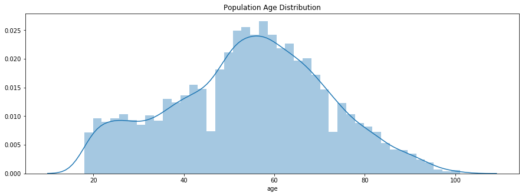

```python
pop_profile = profile.dropna()
plt.figure(figsize=(15,5))
ax = sns.distplot(pop_profile['age'])
ax.set_title('Population Age Distribution')
plt.show()
```

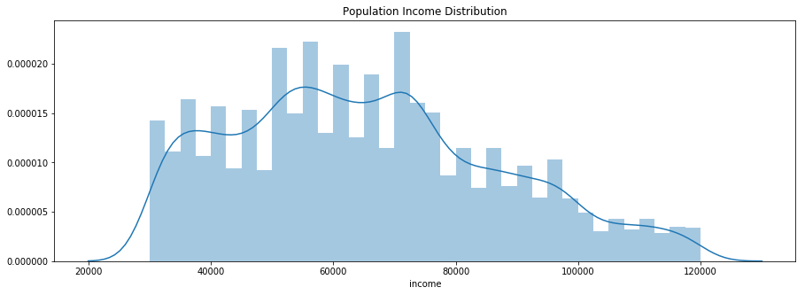

```python
plt.figure(figsize=(15,5))
ax = sns.distplot(pop_profile['income'])
ax.set_title('Population Income Distribution')
plt.show()
```

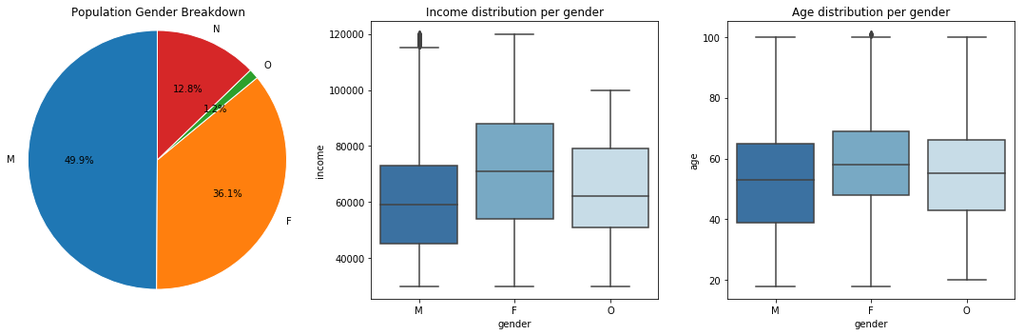

```python
fig, (ax1,ax2,ax3) = plt.subplots(1,3, figsize=(15,5))

# Population Gender Breakdown
gender = profile['gender'].value_counts(normalize=True)[['M', 'F', 'O','N']]
sns.set_palette(sns.color_palette("RdBu_r", 7))
ax1.pie(gender, labels=gender.index, autopct='%1.1f%%', startangle=90, wedgeprops={"edgecolor":"white",'linewidth': 1})
ax1.axis('equal')
ax1.set_title('Population Gender Breakdown')

# Income distribution per gender
sns.boxplot('gender', 'income', data=profile, ax=ax2,order=['M', 'F', 'O'])
ax2.set_title('Income distribution per gender')

# Age distribution per gender
sns.boxplot('gender', 'age', data=profile, ax=ax3,order=['M', 'F', 'O'])
ax3.set_title('Age distribution per gender')

plt.tight_layout()
plt.show()
```

### 3.2. Customer behaviors

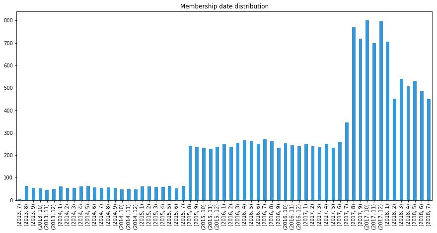

```python
plt.figure(figsize=(15,7))
pop_profile['became_member_on'].groupby([pop_profile['became_member_on'].dt.year, pop_profile['became_member_on'].dt.month]).count().plot(kind="bar",color='#3498db')
plt.title('Membership date distribution')
plt.xlabel('')
plt.show()
```

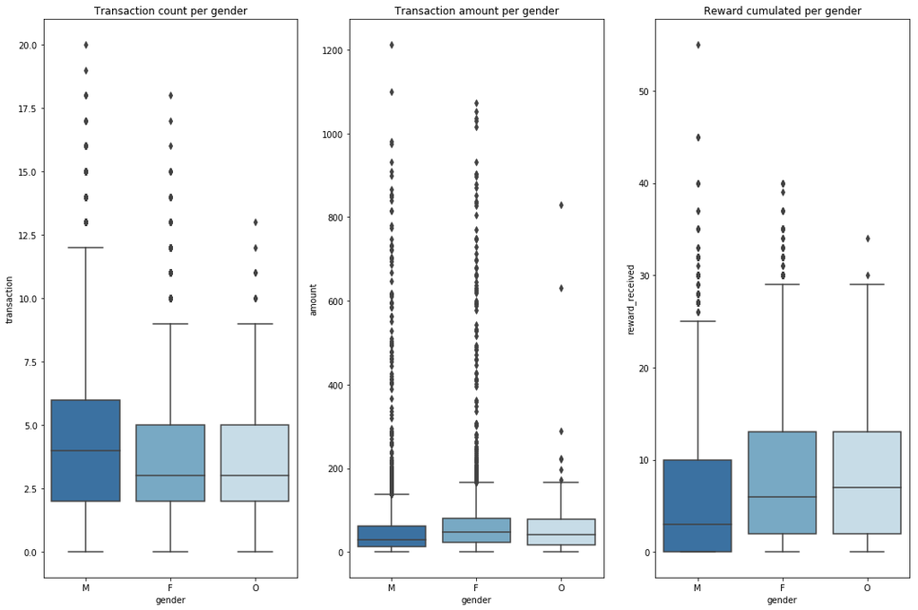

```python
fig, (ax1,ax2,ax3) = plt.subplots(1,3, figsize=(15,10))

gender_behavior = pd.DataFrame(df.groupby(['customer_id','gender']).sum())
gender_behavior = gender_behavior.reset_index(level=['customer_id', 'gender'])

# Total transaction per gender
sns.boxplot('gender', 'transaction', data=gender_behavior, ax=ax1,order=['M', 'F', 'O'])
ax1.set_title('Transaction count per gender')

# Spending per gender
sns.boxplot('gender', 'amount', data=gender_behavior, ax=ax2,order=['M', 'F', 'O'])
ax2.set_title('Transaction amount per gender')

# Spending per gender
sns.boxplot('gender', 'reward_received', data=gender_behavior, ax=ax3,order=['M', 'F', 'O'])
ax3.set_title('Reward cumulated per gender')

plt.tight_layout()
plt.show()
```

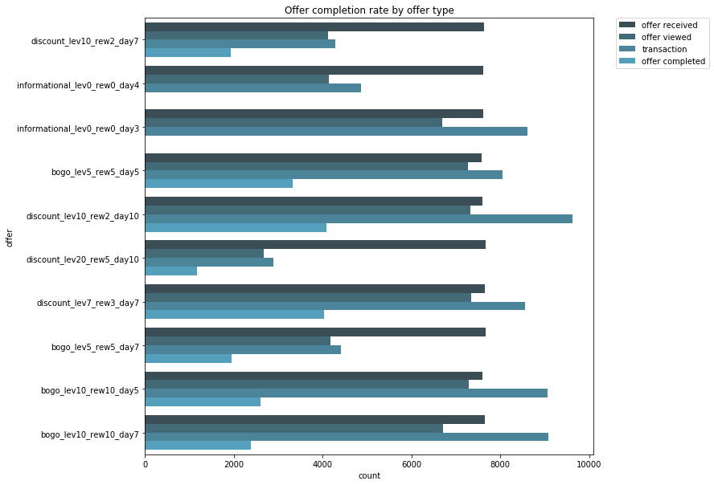

```python
sns.set_palette(sns.color_palette("GnBu_d", 7))
plt.figure(figsize=(10,10))
ax = sns.countplot(y="offer", hue="event", data=df)
ax.set_title('Offer completion rate by offer type')
plt.legend(bbox_to_anchor=(1.05, 1), loc=2, borderaxespad=0.)
plt.show()
```

```
Text(0.5,1,'Customer profile - Features Correlation')
```

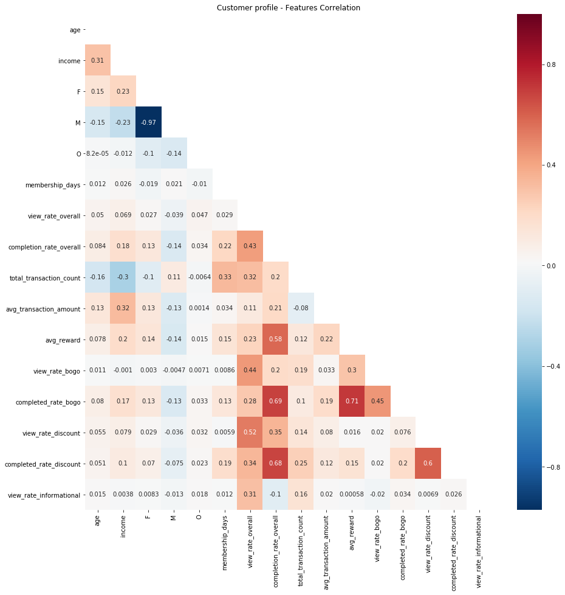

```python
cols = ['age', 'income','F','M','O','membership_days', 'view_rate_overall', 'completion_rate_overall',
       'total_transaction_count','avg_transaction_amount','avg_reward',
       'view_rate_bogo','completed_rate_bogo','view_rate_discount','completed_rate_discount',
       'view_rate_informational']

corr = df1_customer[cols].corr()

f,ax = plt.subplots(figsize=(15,15))
mask = np.zeros_like(corr)
mask[np.triu_indices_from(mask)] = True
sns.heatmap(corr, mask=mask, ax=ax,annot=True, cmap="RdBu_r")
ax.set_title("Customer profile - Features Correlation")
```

## 4. Feature Transformation

### 4.1. Apply Feature Scaling

```python
df_customer_feat = df1_customer
```

```python
# Apply feature scaling to the customer data to obtain a mean of 0 and standard deviation of 1
scaler = StandardScaler()
customer_scaled = pd.DataFrame(scaler.fit_transform(df_customer_feat))
customer_scaled.columns = df_customer_feat.columns
customer_scaled.index = df_customer_feat.index
customer_scaled.head()
```

|  | age | income | F | M | O | membership_days | view_rate_overall | completion_rate_overall | total_transaction_count | avg_transaction_amount | ... | view_rate_informational_lev0_rew0_day3 | view_rate_informational_lev0_rew0_day4 | completed_rate_bogo_lev10_rew10_day5 | completed_rate_bogo_lev10_rew10_day7 | completed_rate_bogo_lev5_rew5_day5 | completed_rate_bogo_lev5_rew5_day7 | completed_rate_discount_lev10_rew2_day10 | completed_rate_discount_lev10_rew2_day7 | completed_rate_discount_lev20_rew5_day10 | completed_rate_discount_lev7_rew3_day7 |
| --- | --- | --- | --- | --- | --- | --- | --- | --- | --- | --- | --- | --- | --- | --- | --- | --- | --- | --- | --- | --- | --- |
| 0 | -1.230528 | 0.305263 | -0.839371 | 0.864373 | -0.120464 | -0.146615 | 0.196713 | -1.146700 | -0.716769 | 0.148228 | ... | 1.437542 | 2.071307 | -0.418965 | -0.397436 | -0.474781 | -0.351371 | -0.535695 | -0.347222 | -0.269176 | -0.529312 |
| 2 | -0.827813 | -0.389288 | -0.839371 | -1.156907 | 8.301227 | -0.773977 | 1.042312 | 0.317665 | -0.356806 | 0.060374 | ... | 1.437542 | 2.071307 | -0.418965 | -0.397436 | -0.474781 | 3.039772 | -0.535695 | -0.347222 | -0.269176 | 1.966889 |
| 3 | 0.265272 | 1.138725 | 1.191369 | -1.156907 | -0.120464 | 0.838557 | -0.648886 | -0.414517 | -0.356806 | 0.313296 | ... | 1.437542 | -0.500575 | -0.418965 | -0.397436 | -0.474781 | -0.351371 | 0.701893 | -0.347222 | -0.269176 | -0.529312 |
| 4 | -1.748305 | -0.250378 | 1.191369 | -1.156907 | -0.120464 | 0.237435 | 1.042312 | 1.598985 | 1.083047 | -0.034485 | ... | 1.437542 | -0.500575 | -0.418965 | -0.397436 | 2.207770 | 3.039772 | -0.535695 | -0.347222 | -0.269176 | 1.966889 |
| 5 | -1.633244 | 0.351567 | 1.191369 | -1.156907 | -0.120464 | -0.292125 | 0.196713 | 0.317665 | 1.802974 | -0.536968 | ... | 1.437542 | 2.071307 | -0.418965 | -0.397436 | -0.474781 | -0.351371 | 1.939481 | -0.347222 | -0.269176 | -0.529312 |

5 rows × 60 columns

### 4.2. Perform Dimensionality Reduction

```python
# Apply PCA to the data
pca = PCA().fit(customer_scaled)
```

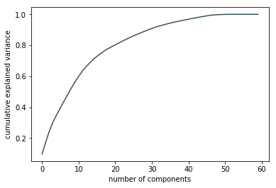

```python
# Investigate the variance accounted for by each principal component.
plt.plot(np.cumsum(pca.explained_variance_ratio_))
plt.xlabel('number of components')
plt.ylabel('cumulative explained variance')
plt.show()
```

```python
th = pd.DataFrame(np.cumsum(pca.explained_variance_ratio_)).head(30)
th
```

|  | 0 |
| --- | --- |
| 0 | 0.097022 |
| 1 | 0.173823 |
| 2 | 0.245808 |
| 3 | 0.304500 |
| 4 | 0.351070 |
| 5 | 0.395927 |
| 6 | 0.439162 |
| 7 | 0.481545 |
| 8 | 0.523706 |
| 9 | 0.563070 |
| 10 | 0.599069 |
| 11 | 0.632638 |
| 12 | 0.660697 |
| 13 | 0.685671 |
| 14 | 0.709358 |
| 15 | 0.728468 |
| 16 | 0.746218 |
| 17 | 0.763170 |
| 18 | 0.777447 |
| 19 | 0.790536 |
| 20 | 0.802876 |
| 21 | 0.814929 |
| 22 | 0.826901 |
| 23 | 0.838685 |
| 24 | 0.850188 |
| 25 | 0.860858 |
| 26 | 0.870950 |
| 27 | 0.880639 |
| 28 | 0.890245 |
| 29 | 0.899412 |

```python
# We reduced the dimensionality to 20 components as it can explain 80% of the variance
# while the number of features are reduced by 66%.
reduced_pca = PCA(n_components=20)
customer_pca = reduced_pca.fit_transform(customer_scaled)
```

### 4.3. Interpret Principal Components

```python
# Function to map weights for the principal component to corresponding feature names

def pca_weight(pca, i):
    df = pd.DataFrame(pca.components_, columns=list(customer_scaled.columns))
    weight = df.iloc[i].sort_values(ascending=False)

    fig, ax = plt.subplots(figsize=(10,20))
    ax = sns.barplot(weight, weight.index)
    return ax
```

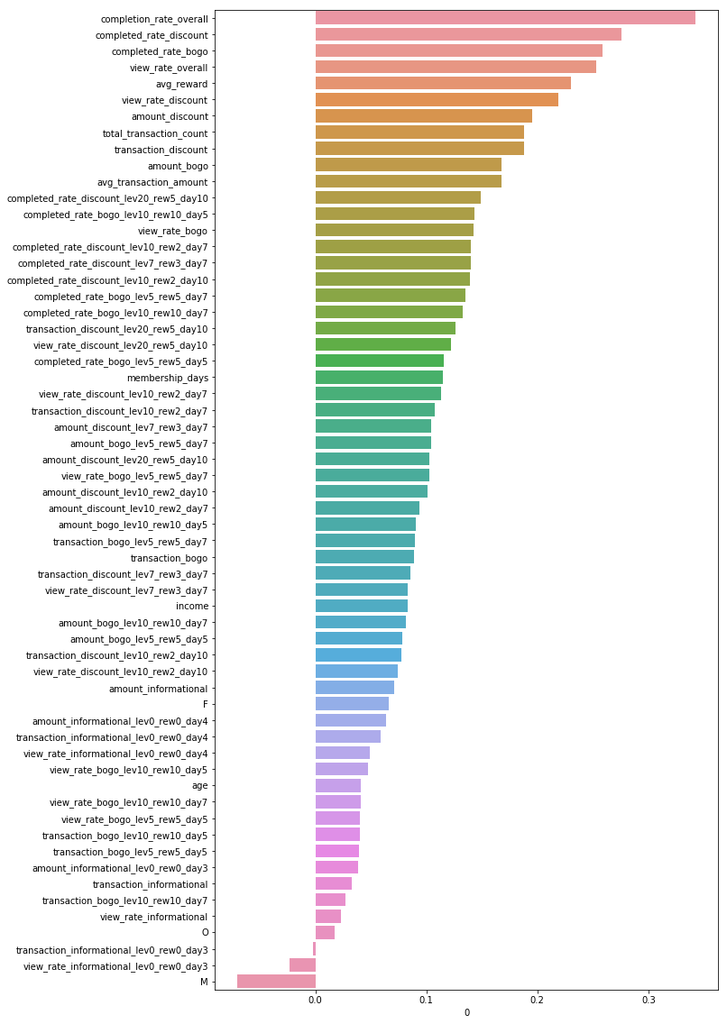

```python
# First principal component weights
first_principal_weight = pca_weight(reduced_pca, 0)
first_principal_weight
```

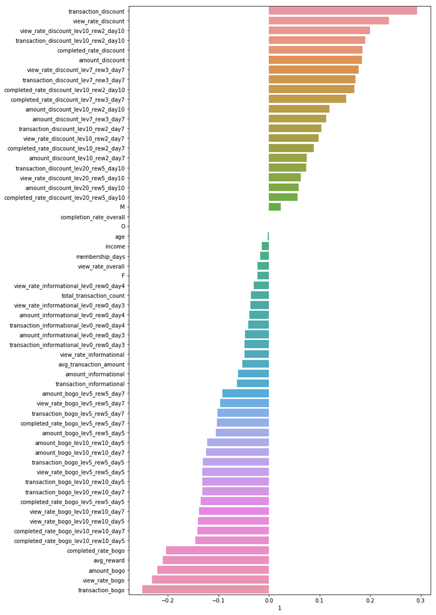

```python
# Second principal component weights
second_principal_weight = pca_weight(reduced_pca, 1)
second_principal_weight
```

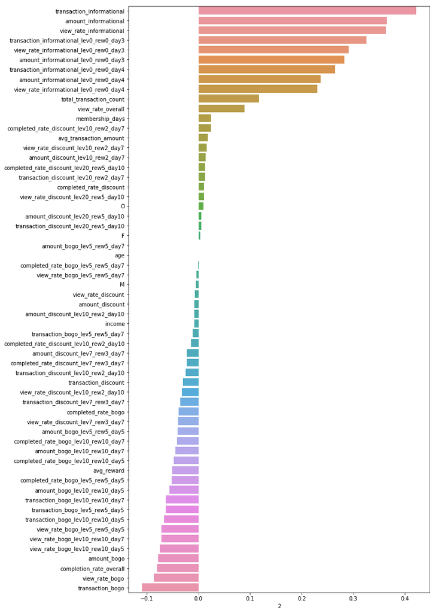

```python
# Third principal component weights
third_principal_weight = pca_weight(reduced_pca, 2)
third_principal_weight
```

## 5. Clustering

### 5.1. Apply Clustering

#### 5.1.1 Elbow Method

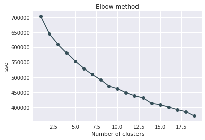

```python
# Elbow method to investigate the change in within-cluster distance across number of clusters.
sse = []

sns.set_palette(sns.color_palette("GnBu_d", 7))

for i in tqdm(list(range(1,20))):
    km = KMeans(n_clusters = i)
    model = km.fit(customer_pca)
    sse.append(np.abs(model.score(customer_pca)))

plt.plot(range(1, 20), sse, marker='o')
plt.title('Elbow method')
plt.xlabel('Number of clusters')
plt.ylabel('sse')
plt.show()
```

#### 5.1.2 Silhouette analysis

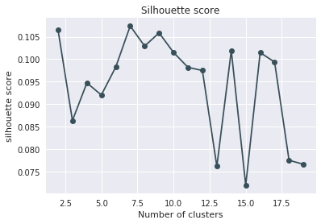

```python
scores = []
for i in tqdm(list(range(2,20))):
    km = KMeans(n_clusters=i)
    preds = km.fit_predict(customer_pca)
    score = silhouette_score(customer_pca, preds)
    scores.append(score)

plt.plot(range(2, 20), scores, marker='o')
plt.title('Silhouette score')
plt.xlabel('Number of clusters')
plt.ylabel('silhouette score')
plt.show()
```

```python
scores
```

[output not shown]

```python
# Re-fit the k-means model with the selected number of clusters and obtain cluster predictions
km = KMeans(n_clusters = 6)
model = km.fit(customer_pca)
cluster_pred = model.predict(customer_pca)
```

### 5.2. Cluster Analysis

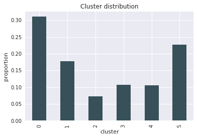

```python
# Compare the proportion of data in each cluster
unique_elements, counts_elements = np.unique(cluster_pred, return_counts=True)
cluster_prop = pd.DataFrame(counts_elements, columns = ['count'], index =unique_elements)
cluster_prop['ratio'] = cluster_prop['count']/cluster_prop['count'].sum()
cluster_prop.drop(['count'] , axis=1, inplace=True)

ax = cluster_prop.plot.bar(legend=False)
ax.set_title('Cluster distribution')
ax.set_xlabel("cluster")
ax.set_ylabel("proportion")
plt.show()
```

```python
cluster_prop
```

|  | ratio |
| --- | --- |
| 0 | 0.310168 |
| 1 | 0.177383 |
| 2 | 0.072397 |
| 3 | 0.107483 |
| 4 | 0.105796 |
| 5 | 0.226773 |

```python
pd.set_option('display.max_rows', 500)

centers = km.cluster_centers_
centers_pca = reduced_pca.inverse_transform(centers)
centers = scaler.inverse_transform(centers_pca)
centers = pd.DataFrame(centers, columns= df_customer_feat.columns)
centers.T
```

|  | 0 | 1 | 2 | 3 | 4 | 5 |
| --- | --- | --- | --- | --- | --- | --- |
| age | 52.261290 | 57.666132 | 55.858191 | 52.947081 | 54.965398 | 54.682324 |
| income | 61464.128153 | 70176.499754 | 69402.287172 | 63171.599054 | 67479.806137 | 65888.820367 |
| F | 0.314626 | 0.514744 | 0.480605 | 0.425875 | 0.445268 | 0.426719 |
| M | 0.674212 | 0.471065 | 0.494075 | 0.560928 | 0.539556 | 0.557991 |
| O | 0.011162 | 0.014190 | 0.025320 | 0.013197 | 0.015176 | 0.015291 |
| membership_days | 308.916325 | 555.763828 | 631.644760 | 671.085808 | 668.861529 | 614.880107 |
| view_rate_overall | 62.062385 | 72.572877 | 92.684934 | 82.541418 | 86.999062 | 81.304904 |
| completion_rate_overall | 4.444749 | 38.381594 | 57.559153 | 27.464373 | 50.242656 | 47.187227 |
| total_transaction_count | 2.243066 | 3.598018 | 4.774194 | 6.380230 | 4.768602 | 4.944511 |
| avg_transaction_amount | 7.721047 | 20.454316 | 19.681727 | 17.346315 | 16.535246 | 14.826909 |
| avg_reward | 1.095652 | 6.361063 | 5.091869 | 3.700791 | 3.552883 | 3.728171 |
| transaction_bogo | 1.093331 | 2.792369 | 1.424891 | 1.875010 | 1.509591 | 2.051687 |
| transaction_discount | 0.726746 | 0.319982 | 2.645367 | 1.121611 | 2.540775 | 2.489322 |
| transaction_informational | 0.422990 | 0.485667 | 0.703936 | 3.383609 | 0.718237 | 0.403502 |
| amount_bogo | 4.269468 | 53.821321 | 24.612791 | 17.438882 | 20.525221 | 21.801969 |
| amount_discount | 4.311742 | 4.770970 | 53.639709 | 12.807060 | 40.584172 | 33.858532 |
| amount_informational | 2.647718 | 5.454894 | 11.474526 | 65.732746 | 9.106660 | 3.245650 |
| view_rate_bogo | 59.635703 | 97.686393 | 75.336638 | 68.162302 | 72.266606 | 76.509627 |
| view_rate_discount | 45.294917 | 30.303815 | 97.892618 | 50.456916 | 93.469714 | 85.605398 |
| view_rate_informational | 37.477864 | 35.452952 | 44.771304 | 106.558663 | 42.692735 | 29.023636 |
| completed_rate_bogo | -0.949597 | 70.560257 | 52.297499 | 36.711971 | 42.526054 | 38.445281 |
| completed_rate_discount | 7.257767 | 10.388335 | 73.236837 | 38.788968 | 67.752178 | 64.917053 |
| transaction_bogo_lev10_rew10_day5 | 0.355127 | 0.808277 | 0.370078 | 0.562859 | 0.460843 | 0.602915 |
| transaction_bogo_lev10_rew10_day7 | 0.377946 | 0.770135 | 0.418630 | 0.577192 | 0.398170 | 0.644462 |
| transaction_bogo_lev5_rew5_day5 | 0.280200 | 0.767064 | 0.348970 | 0.447541 | 0.395271 | 0.537453 |
| transaction_bogo_lev5_rew5_day7 | 0.080059 | 0.446893 | 0.287212 | 0.287418 | 0.255307 | 0.266858 |
| transaction_discount_lev10_rew2_day10 | 0.335610 | 0.101127 | 0.365463 | 0.513363 | 0.491432 | 1.285825 |
| transaction_discount_lev10_rew2_day7 | 0.061879 | 0.058490 | 0.222315 | 0.097370 | 1.604790 | 0.032084 |
| transaction_discount_lev20_rew5_day10 | 0.041112 | 0.038790 | 1.690816 | 0.046185 | 0.028709 | 0.030706 |
| transaction_discount_lev7_rew3_day7 | 0.288145 | 0.121575 | 0.366772 | 0.464692 | 0.415844 | 1.140707 |
| transaction_informational_lev0_rew0_day3 | 0.321144 | 0.292949 | 0.403270 | 2.205594 | 0.457491 | 0.236248 |
| transaction_informational_lev0_rew0_day4 | 0.101846 | 0.192719 | 0.300667 | 1.178015 | 0.260746 | 0.167254 |
| amount_bogo_lev10_rew10_day5 | 1.559471 | 15.788725 | 6.514496 | 4.463500 | 6.544030 | 5.941554 |
| amount_bogo_lev10_rew10_day7 | 1.146143 | 16.099051 | 6.021501 | 4.545039 | 5.425119 | 5.962588 |
| amount_bogo_lev5_rew5_day5 | 1.226836 | 14.954726 | 7.015095 | 4.314072 | 4.324568 | 6.622558 |
| amount_bogo_lev5_rew5_day7 | 0.337018 | 6.978820 | 5.061700 | 4.116271 | 4.231504 | 3.275270 |
| amount_discount_lev10_rew2_day10 | 2.198547 | 1.920331 | 4.194182 | 6.426454 | 4.763471 | 18.999853 |
| amount_discount_lev10_rew2_day7 | 0.439947 | 0.820397 | 3.199230 | 0.611652 | 31.503762 | -1.167345 |
| amount_discount_lev20_rew5_day10 | 0.183761 | 0.145144 | 41.505603 | 0.192267 | -1.095811 | -0.469091 |
| amount_discount_lev7_rew3_day7 | 1.489487 | 1.885098 | 4.740693 | 5.576685 | 5.412749 | 16.495115 |
| amount_informational_lev0_rew0_day3 | 1.850095 | 3.016643 | 6.179073 | 38.943169 | 5.084989 | 1.618818 |
| amount_informational_lev0_rew0_day4 | 0.797623 | 2.438251 | 5.295453 | 26.789577 | 4.021671 | 1.626832 |
| view_rate_bogo_lev10_rew10_day5 | 29.268989 | 55.174185 | 30.486911 | 30.394580 | 31.158666 | 35.598321 |
| view_rate_bogo_lev10_rew10_day7 | 27.031768 | 48.119948 | 30.685423 | 28.144360 | 28.056015 | 35.199628 |
| view_rate_bogo_lev5_rew5_day5 | 28.062993 | 54.131557 | 29.611915 | 27.963370 | 31.524709 | 37.424166 |
| view_rate_bogo_lev5_rew5_day7 | 11.267661 | 30.941057 | 26.713720 | 18.988571 | 20.936889 | 19.427268 |
| view_rate_discount_lev10_rew2_day10 | 30.655614 | 10.753088 | 29.135409 | 28.445187 | 32.816944 | 70.454466 |
| view_rate_discount_lev10_rew2_day7 | 11.259425 | 7.326513 | 23.027867 | 8.165574 | 100.487642 | 6.153598 |
| view_rate_discount_lev20_rew5_day10 | 7.650819 | 5.207715 | 99.517801 | 4.015537 | 7.470669 | 3.575238 |
| view_rate_discount_lev7_rew3_day7 | 28.934514 | 14.208682 | 31.867378 | 29.164645 | 32.296487 | 67.384123 |
| view_rate_informational_lev0_rew0_day3 | 31.012289 | 25.170459 | 27.196612 | 86.285882 | 29.580298 | 19.880407 |
| view_rate_informational_lev0_rew0_day4 | 14.638833 | 16.293357 | 24.145894 | 49.519815 | 19.580161 | 12.747682 |
| completed_rate_bogo_lev10_rew10_day5 | -2.075047 | 37.923157 | 21.025976 | 14.293989 | 17.071456 | 15.224874 |
| completed_rate_bogo_lev10_rew10_day7 | -2.000413 | 32.667883 | 18.934095 | 13.467148 | 15.895483 | 14.951755 |
| completed_rate_bogo_lev5_rew5_day5 | 1.573149 | 37.496220 | 21.899072 | 17.213982 | 19.797514 | 22.183547 |
| completed_rate_bogo_lev5_rew5_day7 | -0.411664 | 21.666358 | 18.983365 | 12.114200 | 13.072838 | 11.408274 |
| completed_rate_discount_lev10_rew2_day10 | 6.968901 | 2.566744 | 24.164687 | 23.252524 | 24.484585 | 53.724990 |
| completed_rate_discount_lev10_rew2_day7 | 0.171947 | 1.212934 | 14.263504 | 5.787743 | 71.235826 | 3.098229 |
| completed_rate_discount_lev20_rew5_day10 | -0.299238 | 1.327476 | 71.445966 | 2.897517 | 2.576945 | 1.872122 |
| completed_rate_discount_lev7_rew3_day7 | 6.332901 | 4.547662 | 24.707309 | 22.950595 | 25.205151 | 50.749103 |

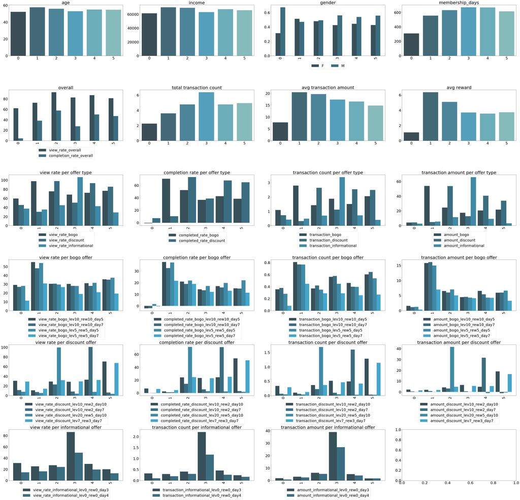

```python
fig, ((ax1,ax2,ax3,ax4), (ax5, ax6,ax7,ax8), (ax9, ax10,ax11,ax12), (ax13, ax14,ax15,ax16),(ax17, ax18, ax19, ax20),
      (ax21, ax22,ax23, ax24))= plt.subplots(nrows=6,ncols=4, figsize=(60,56))

plt.rcParams.update({'font.size': 30})
sns.set_palette(sns.color_palette("GnBu_d", 7))

clusters = centers.index

sns.barplot(x = clusters, y = centers['age'], ax = ax1)
ax1.set_title('age')
ax1.set_ylabel('')

sns.barplot(x = clusters, y = centers['income'], ax = ax2)
ax2.set_title('income')
ax2.set_ylabel('')

centers.plot(y=['F', 'M'], kind="bar", ax = ax3)
ax3.set_title('gender')
ax3.legend(loc='lower center',bbox_to_anchor=(0.5, -0.3),ncol=2)

sns.barplot(x = clusters, y = centers['membership_days'], ax = ax4)
ax4.set_title('membership_days')
ax4.set_ylabel('')

centers.plot(y=['view_rate_overall', 'completion_rate_overall'], kind="bar", ax = ax5)
ax5.set_title('overall')
ax5.legend(loc='lower center',bbox_to_anchor=(0.5, -0.4))

sns.barplot(x = clusters, y = centers['total_transaction_count'], ax = ax6)
ax6.set_title('total transaction count')
ax6.set_ylabel('')

sns.barplot(x = clusters, y = centers['avg_transaction_amount'], ax = ax7)
ax7.set_title('avg transaction amount')
ax7.set_ylabel('')

sns.barplot(x = clusters, y = centers['avg_reward'], ax = ax8)
ax8.set_title('avg reward')
ax8.set_ylabel('')

centers.plot(y=['view_rate_bogo', 'view_rate_discount','view_rate_informational'], kind="bar", ax = ax9, width=0.9)
ax9.set_title('view rate per offer type')
ax9.legend(loc='lower center',bbox_to_anchor=(0.5, -0.5))

centers.plot(y=['completed_rate_bogo', 'completed_rate_discount'], kind="bar", ax = ax10, width=0.9)
ax10.set_title('completion rate per offer type')
ax10.legend(loc='lower center',bbox_to_anchor=(0.5, -0.4))

centers.plot(y=['transaction_bogo', 'transaction_discount','transaction_informational'], kind="bar", ax = ax11, width=0.9)
ax11.set_title('transaction count per offer type')
ax11.legend(loc='lower center',bbox_to_anchor=(0.5, -0.5))

centers.plot(y=['amount_bogo', 'amount_discount','amount_informational'], kind="bar", ax = ax12, width=0.9)
ax12.set_title('transaction amount per offer type')
ax12.legend(loc='lower center',bbox_to_anchor=(0.5, -0.5))

centers.plot(y=['view_rate_bogo_lev10_rew10_day5', 'view_rate_bogo_lev10_rew10_day7',
                'view_rate_bogo_lev5_rew5_day5','view_rate_bogo_lev5_rew5_day7'], kind="bar", ax = ax13, width=0.9)
ax13.set_title('view rate per bogo offer')
ax13.legend(loc='lower center',bbox_to_anchor=(0.5, -0.6))

centers.plot(y=['completed_rate_bogo_lev10_rew10_day5', 'completed_rate_bogo_lev10_rew10_day7',
                'completed_rate_bogo_lev5_rew5_day5','completed_rate_bogo_lev5_rew5_day7'], kind="bar", ax = ax14, width=0.9)
ax14.set_title('completion rate per bogo offer')
ax14.legend(loc='lower center',bbox_to_anchor=(0.5, -0.6))

centers.plot(y=['transaction_bogo_lev10_rew10_day5', 'transaction_bogo_lev10_rew10_day7',
                'transaction_bogo_lev5_rew5_day5','transaction_bogo_lev5_rew5_day7'], kind="bar", ax = ax15, width=0.9)
ax15.set_title('transaction count per bogo offer')
ax15.legend(loc='lower center',bbox_to_anchor=(0.5, -0.6))

centers.plot(y=['amount_bogo_lev10_rew10_day5', 'amount_bogo_lev10_rew10_day7',
                'amount_bogo_lev5_rew5_day5','amount_bogo_lev5_rew5_day7'], kind="bar", ax = ax16,width=0.9)
ax16.set_title('transaction amount per bogo offer')
ax16.legend(loc='lower center',bbox_to_anchor=(0.5, -0.6))

centers.plot(y=['view_rate_discount_lev10_rew2_day10', 'view_rate_discount_lev10_rew2_day7',
                'view_rate_discount_lev20_rew5_day10','view_rate_discount_lev7_rew3_day7'], kind="bar", ax = ax17,width=0.9)
ax17.set_title('view rate per discount offer')
ax17.legend(loc='lower center',bbox_to_anchor=(0.5, -0.6))

centers.plot(y=['completed_rate_discount_lev10_rew2_day10', 'completed_rate_discount_lev10_rew2_day7',
                'completed_rate_discount_lev20_rew5_day10','completed_rate_discount_lev7_rew3_day7'], kind="bar", ax = ax18,width=0.9)
ax18.set_title('completion rate per discount offer')
ax18.legend(loc='lower center',bbox_to_anchor=(0.5, -0.6))

centers.plot(y=['transaction_discount_lev10_rew2_day10', 'transaction_discount_lev10_rew2_day7',
                'transaction_discount_lev20_rew5_day10','transaction_discount_lev7_rew3_day7'], kind="bar", ax = ax19,width=0.9)
ax19.set_title('transaction count per discount offer')
ax19.legend(loc='lower center',bbox_to_anchor=(0.5, -0.6))

centers.plot(y=['amount_discount_lev10_rew2_day10', 'amount_discount_lev10_rew2_day7',
                'amount_discount_lev20_rew5_day10','amount_discount_lev7_rew3_day7'], kind="bar", ax = ax20,width=0.9)
ax20.set_title('transaction amount per discount offer')
ax20.legend(loc='lower center',bbox_to_anchor=(0.5, -0.6))

centers.plot(y=['view_rate_informational_lev0_rew0_day3', 'view_rate_informational_lev0_rew0_day4'],
                 kind="bar", ax = ax21,width=0.9)
ax21.set_title('view rate per informational offer')
ax21.legend(loc='lower center',bbox_to_anchor=(0.5, -0.4))

centers.plot(y=['transaction_informational_lev0_rew0_day3', 'transaction_informational_lev0_rew0_day4'],
                 kind="bar", ax = ax22,width=0.9)
ax22.set_title('transaction count per informational offer')
ax22.legend(loc='lower center',bbox_to_anchor=(0.5, -0.4))

centers.plot(y=['amount_informational_lev0_rew0_day3', 'amount_informational_lev0_rew0_day4'],
                 kind="bar", ax = ax23,width=0.9)
ax23.set_title('transaction amount per informational offer')
ax23.legend(loc='lower center',bbox_to_anchor=(0.5, -0.4))

plt.tight_layout(h_pad=7)
plt.show()
```

### Visualising Customers Cluster with TSNE

```python
tsne = TSNE().fit_transform(customer_pca)
tsne_df = pd.DataFrame(tsne, columns=['xs', 'ys'])
tsne_df['cluster'] = [str(i) for i in cluster_pred]
```

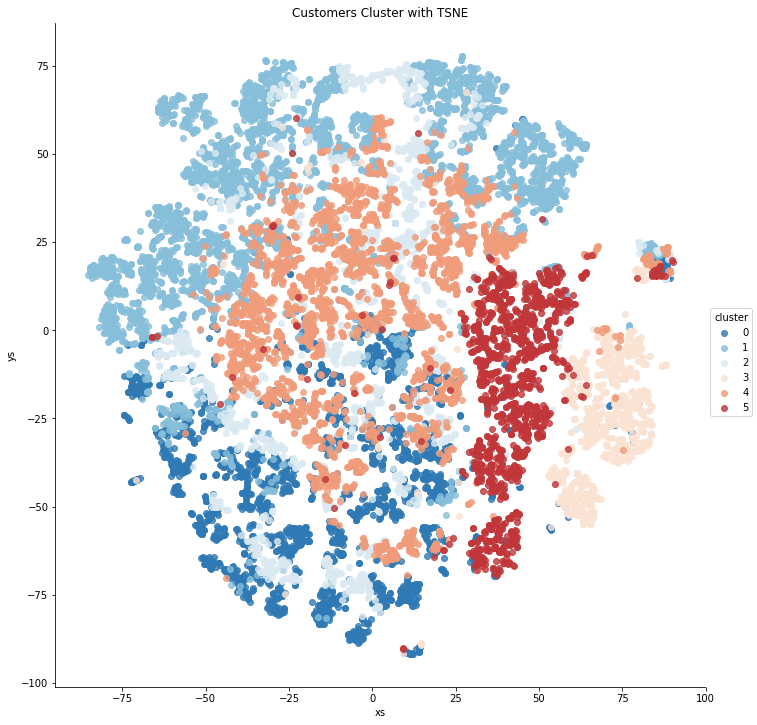

```python
#plot tsne
sns.lmplot(x='xs',y='ys', data=tsne_df, hue='cluster', size = 10, fit_reg=False, legend=True, palette="RdBu_r")
plt.title("Customers Cluster with TSNE")
plt.show()
```

```python
tsne_df.shape
```

```
(14821, 3)
```